# Forecasting US Candy Production

brp107@scarletmail.rutgers.edu

10/3/2026

```r
library(fpp2)
library(TTR)

candy_production <- read.csv("candy_production.csv")
candy_ts <- ts(candy_production$IPG3113N, start = c(1972, 1), frequency = 12)

attributes(candy_ts)
```

```
## $tsp
## [1] 1972.000 2017.583   12.000
##
## $class
## [1] "ts"
```

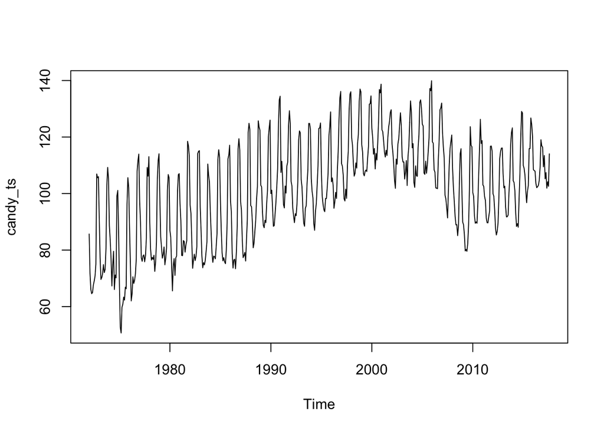

```r
plot(candy_ts)
```

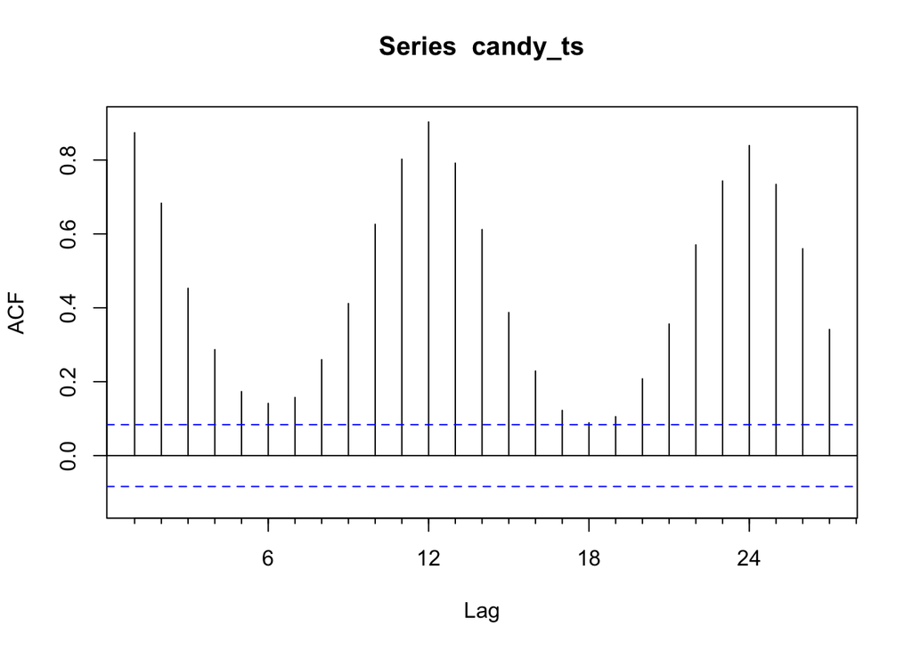

```r
Acf(candy_ts)
```

**Explanation:** `attributes()` confirms that `candy_ts` is a time series running from 1972 to 2017 with a frequency of 12, monthly data. The plot shows a long-run upward trend through about 2005, a drop around 2007 to 2009, and a clear repeating yearly pattern with production peaking every fall. The ACF confirms the seasonality, the autocorrelation spikes at lag 12 (about 0.90) and lag 24 (about 0.84), so each month is strongly related to the same month in previous years. Models that account for seasonality should perform best.

## Mean Forecasting

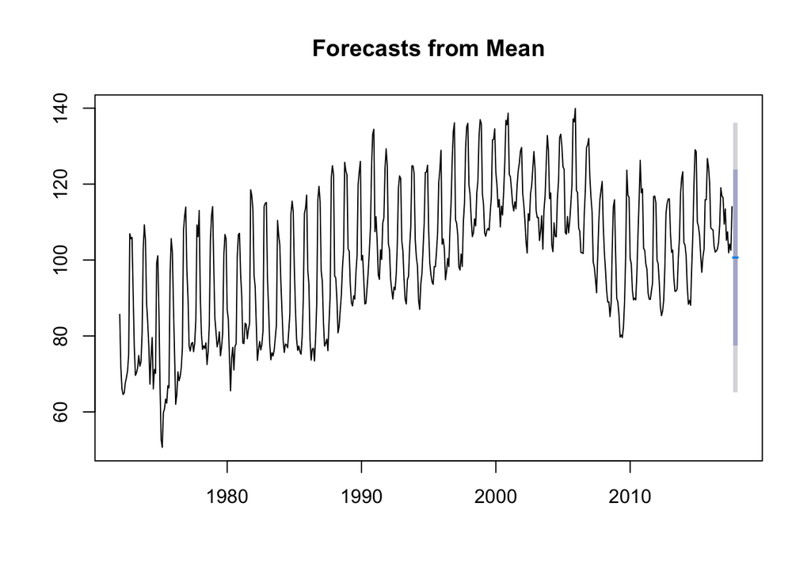

```r
mean_forecast <- meanf(candy_ts,5)
plot(mean_forecast)
```

**Explanation:** The mean method forecasts every future month as the average of all past observations, 100.66. The forecast is a flat line that ignores both the trend and the seasonal pattern, so it only serves as a baseline. The shaded 80% and 95% prediction intervals are very wide (roughly 77 to 124 at 80%) because the data varies a lot around its overall average.

#Naive

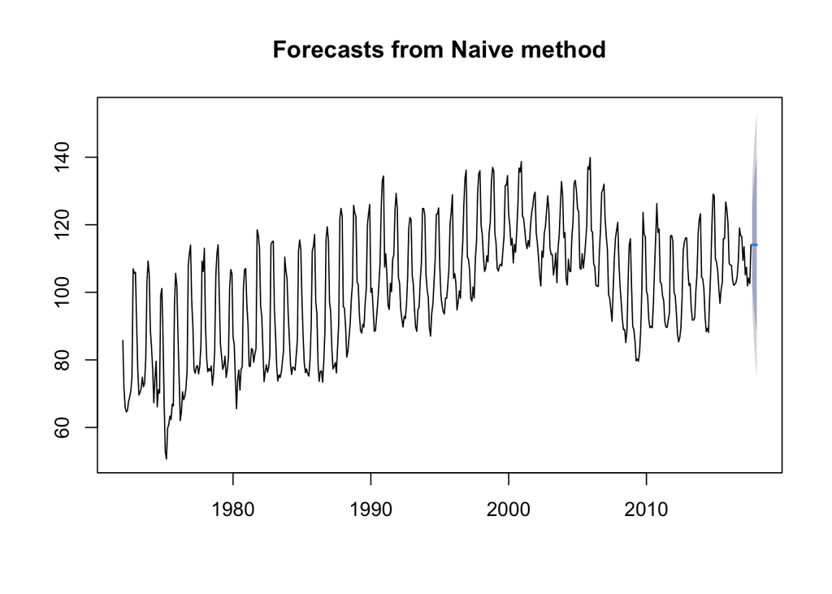

```r
naive_forecast <- naive(candy_ts,5)
plot(naive_forecast)
```

**Explanation:** The naiven method uses the last observed value, 114.06 (August 2017), as the forecast for every future month. It reflects the recent level better than the mean, but it misses the fall holiday peak. Its prediction intervals widen with each month ahead, because uncertainty builds the further out it forecasts.

## Random Walk

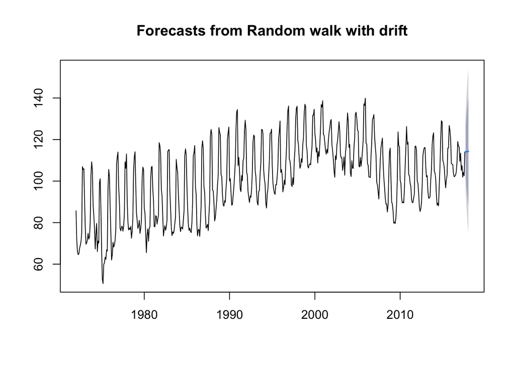

```r
rwf_forecast <- rwf(candy_ts,5)
rwf_forecast <- rwf(candy_ts,5, drift=TRUE)
plot(rwf_forecast)
```

**Explanation:** Without drift, the random walk forecast is identical to the naive forecast. It adds the average monthly change across the whole history, about 0.05 index points per month, so the forecast rises very slightly. That drift is tiny compared with the seasonal swings, this forecast is almost the same as the naive one and still has no seasonality.

## Seasonal Naive

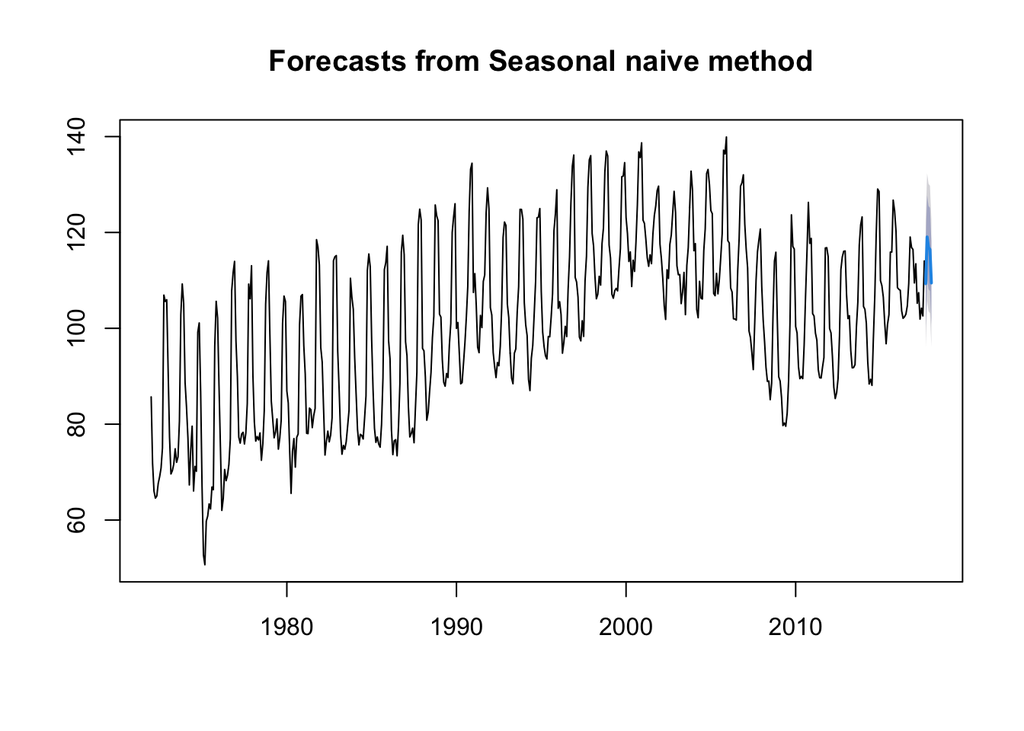

```r
snaive_forecast <- snaive(candy_ts,5)
plot(snaive_forecast)
```

**Explanation:** The seasonal naive method forecasts each month with the value from the same month one year earlier. For example, the October 2017 forecast (119.05) is October 2016’s actual value. This is the first model here that captures the seasonal pattern: it forecasts a rise into October and a drop in January.

## Moving Averages

```r
MA5_forecast <- ma(candy_ts, order = 5)
MA9_forecast <- ma(candy_ts, order = 10)
MA15_forecast <- ma(candy_ts, order = 15)
```

**Explanation:** `ma()` creates a centered moving average, which smooths the series by averaging each month with the months around it. MA(5) averages 5 months MA(10) averages 10 months, and MA(15) averages 15 months so it is smoother. It is centered, thats why it uses future values and cannot extend past the last few observations. That makes it a smoothing tool for seeing the underlying level rather than a true forecast.

## Plot in Single Chart

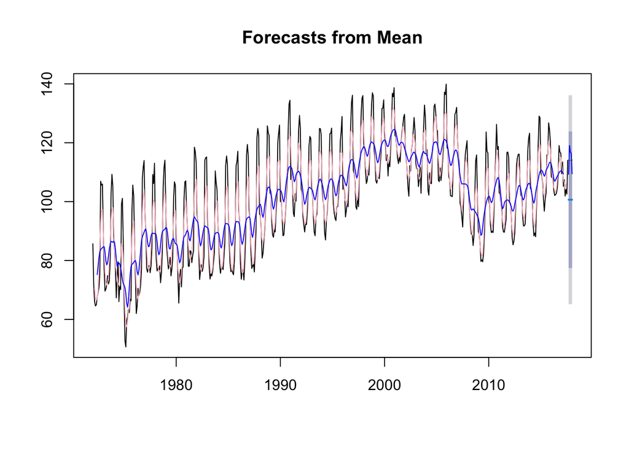

```r
plot(mean_forecast)
lines(naive_forecast$mean,col="red")
lines(rwf_forecast$mean,col="green")
lines(snaive_forecast$mean,col="blue")
lines(MA5_forecast,col="Pink")
lines(MA9_forecast,col="Blue")
```

```r
attributes(naive_forecast)
```

```
## $names
##  [1] "method"    "model"     "lambda"    "x"         "fitted"    "residuals"
##  [7] "series"    "mean"      "level"     "lower"     "upper"
##
## $class
## [1] "forecast"
```

## Holt Winters

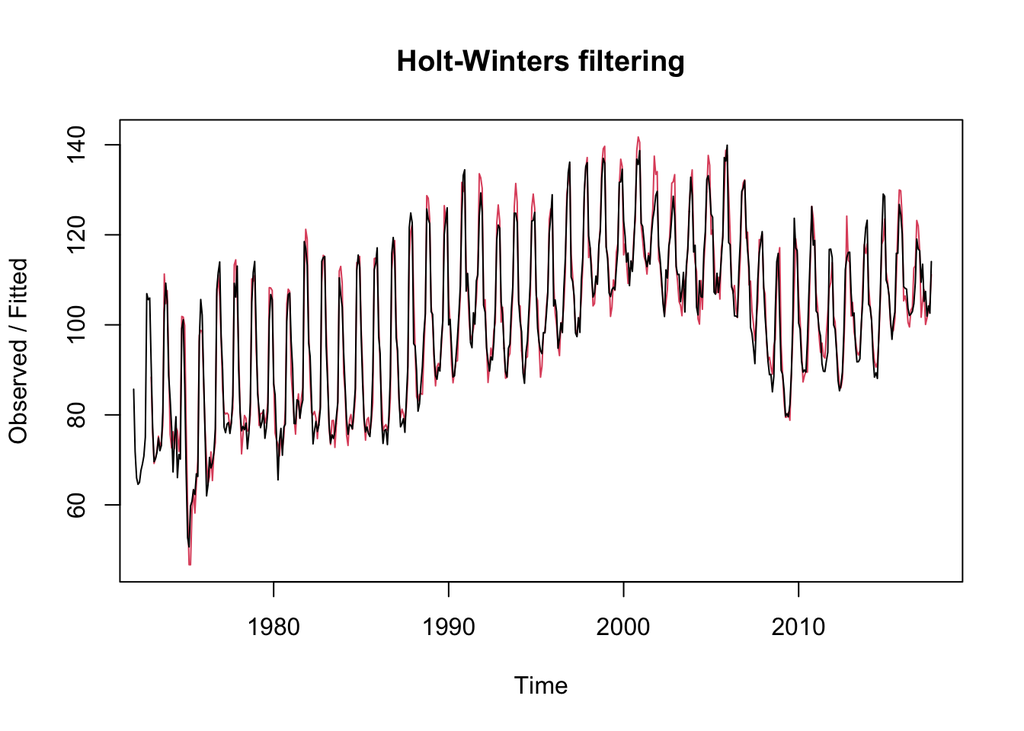

```r
HW_forecast <- HoltWinters(candy_ts)
plot(HW_forecast)
```

```r
SSE_Simple <- HoltWinters(candy_ts,beta=FALSE,gamma=FALSE)
attributes(SSE_Simple)
```

```
## $names
## [1] "fitted"       "x"            "alpha"        "beta"         "gamma"
## [6] "coefficients" "seasonal"     "SSE"          "call"
##
## $class
## [1] "HoltWinters"
```

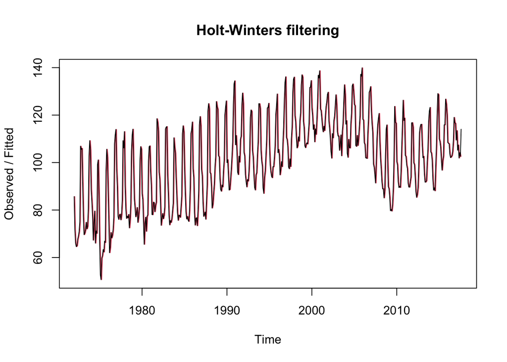

```r
plot(SSE_Simple)
```

```r
SSE_Simple$SSE
```

```
## [1] 44519.34
```

```r
head(SSE_Simple$fitted)
```

```
##              xhat    level
## Feb 1972 85.69450 85.69450
## Mar 1972 71.82092 71.82092
## Apr 1972 66.02328 66.02328
## May 1972 64.56460 64.56460
## Jun 1972 65.00997 65.00997
## Jul 1972 67.64653 67.64653
```

**Explanation:** The full Holt-Winters model estimates level, trend, and seasonality. R chose alpha = 0.602 (level), beta = 0.003 (trend), and gamma = 0.586 (seasonality), with an SSE of 8,151.7. (R gives a warning that the optimizer had difficulty, but it still returns usable parameters.) In its plot, the red fitted line follows the black actual data closely, including the seasonal peaks.

`SSE_Simple` turns off the trend (`beta=FALSE`) and seasonality (`gamma=FALSE`), leaving simple exponential smoothing. Its alpha is about 1, meaning it puts nearly all the weight on the most recent month, so it behaves like the naive method and its fitted line lags one month behind the actual data. Its SSE is 44,519.3, more than five times larger than the full Holt-Winters model, which shows how much is lost by ignoring seasonality. `head(SSE_Simple$fitted)` shows the first fitted values, and `xhat` equals `level` because there is no trend or seasonal component.

## Accuracy Comparison

```r
accuracy(mean_forecast)
```

```
##                        ME     RMSE      MAE      MPE     MAPE     MASE
## Training set 1.009087e-14 18.03645 14.94239 -3.58257 15.98442 2.896657
##                   ACF1
## Training set 0.8740088
```

```r
accuracy(naive_forecast)
```

```
##                      ME     RMSE      MAE       MPE     MAPE     MASE      ACF1
## Training set 0.05185887 9.021386 6.355331 -0.354012 6.376566 1.232013 0.2588251
```

```r
accuracy(rwf_forecast)
```

```
##                         ME     RMSE      MAE        MPE     MAPE     MASE
## Training set -1.214547e-15 9.021237 6.355286 -0.4073621 6.378128 1.232004
##                   ACF1
## Training set 0.2588251
```

```r
accuracy(snaive_forecast)
```

```
##                     ME     RMSE      MAE      MPE     MAPE MASE     ACF1
## Training set 0.6825472 6.778351 5.158494 0.479633 5.397696    1 0.755025
```

```r
accuracy(forecast(HW_forecast))
```

```
##                     ME     RMSE      MAE        MPE     MAPE     MASE      ACF1
## Training set -0.216459 3.899791 2.991261 -0.2665492 3.036667 0.579871 0.1036205
```

```r
accuracy(forecast(SSE_Simple))
```

```
##                      ME    RMSE      MAE       MPE     MAPE     MASE      ACF1
## Training set 0.05186091 9.02154 6.355529 -0.354052 6.376765 1.232051 0.2588924
```

**Conclusion:** Holt-Winters is the best model. Its MPE of -0.27% is the closest to zero, meaning it forecasts only about a quarter of a percent too high on average. It models the level, trend, and seasonal pattern, which suits candy production’s strong holiday cycle. The mean model is the worst, forecasting about 3.6% too high on average. One limitation of MPE is that positive and negative errors cancel out, so it measures bias, not the size of the errors. That is why the naive model looks better than seasonal naive here even though its RMSE is larger (9.02 vs. 6.78). Holt-Winters also has the lowest RMSE (3.90), so it is the best mode.